# Macro Market Direction Model

Bank of Uganda, Petroleum Revenue Investment Reserve (PRIR)

Ibaale Eric

June 05, 2026

# 1 Introduction

This report presents a **Macro Market Direction Model** developed for the Bank of Uganda Petroleum Investment Fund. The fund holds a diversified portfolio composed of 40% Global Stocks, 30% Government Bonds, 20% Corporate Bonds, and 10% Emerging Market assets.

The central objective is to predict, one month in advance, whether the next month will be **favorable** (portfolio performs above its historical median) or **unfavorable** (portfolio performs at or below the median). This is a binary classification problem, and I used **logistic regression** as my primary modelling tool.

# 2 Load Required Libraries

loading all the R packages needed for the analysis.

```r
# Core data manipulation
library(readxl)
library(dplyr)
library(tidyr)
library(lubridate)

# Visualisation
library(ggplot2)
library(gridExtra)
library(corrplot)
library(reshape2)

# Modelling and evaluation
library(caret)
library(pROC)

# Table formatting
library(knitr)
library(kableExtra)
```

# 3 Data Loading and Preparation

## 3.1 Loading the Data

The dataset is a Bloomberg data pull stored in an Excel workbook. The first several rows contain metadata (start date, end date, variable names).

```r
raw <- read_excel("Book1.xlsx", sheet = "Sheet1", col_names = FALSE)

# Row 4 (index 3 in 0-based) contains variable names; actual data starts at row 7
var_names <- c("Date",
               as.character(raw[4, 2:11]))

df_raw <- raw[7:nrow(raw), 1:11]
colnames(df_raw) <- var_names

# Clean column names for easy use in R
colnames(df_raw) <- c("Date","VIX","FDTR","DXY","USGG10YR",
                      "MXEF","SPX","HYG","EURUSD","USGG2YR","CL1")

# Convert types
df_raw$Date <- as.Date(as.numeric(df_raw$Date), origin = "1899-12-30")

numeric_cols <- c("VIX","FDTR","DXY","USGG10YR","MXEF","SPX",
                  "HYG","EURUSD","USGG2YR","CL1")

df_raw[numeric_cols] <- lapply(df_raw[numeric_cols], function(x) as.numeric(as.character(x)))

cat("Dataset dimensions:", nrow(df_raw), "rows x", ncol(df_raw), "columns\n")
```

```
## Dataset dimensions: 420 rows x 11 columns
```

```r
cat("Date range:", format(min(df_raw$Date), "%B %Y"),
    "to", format(max(df_raw$Date), "%B %Y"), "\n")
```

```
## Date range: January 1990 to December 2024
```

## 3.2 Missing Value Assessment

```r
missing_summary <- data.frame(
  Variable = colnames(df_raw),
  Missing   = sapply(df_raw, function(x) sum(is.na(x))),
  Pct_Missing = round(sapply(df_raw, function(x) mean(is.na(x)) * 100), 1)
)
rownames(missing_summary) <- NULL

kable(missing_summary, caption = "Missing Values by Variable",
      col.names = c("Variable", "Count Missing", "% Missing")) %>%
  kable_styling(bootstrap_options = c("striped","hover","condensed"), full_width = FALSE)
```

Missing Values by Variable

| Variable | Count Missing | % Missing |
| --- | --- | --- |
| Date | 0 | 0.0 |
| VIX | 0 | 0.0 |
| FDTR | 0 | 0.0 |
| DXY | 0 | 0.0 |
| USGG10YR | 0 | 0.0 |
| MXEF | 0 | 0.0 |
| SPX | 0 | 0.0 |
| HYG | 207 | 49.3 |
| EURUSD | 0 | 0.0 |
| USGG2YR | 0 | 0.0 |
| CL1 | 0 | 0.0 |

The HYG (High Yield Corporate Bond ETF) column has a substantial number of missing values because the HYG ETF was only launched in 2007. Observations before that date simply do not have HYG data. I handled this by using HYG only where available, and noting the limitation in our feature engineering step.

# 4 Exploratory Data Analysis

## 4.1 Summary Statistics

```r
summary_df <- df_raw %>%
  select(-Date) %>%
  summarise(across(everything(),
    list(
      Mean  = ~round(mean(., na.rm = TRUE), 3),
      SD    = ~round(sd(., na.rm = TRUE), 3),
      Min   = ~round(min(., na.rm = TRUE), 3),
      Max   = ~round(max(., na.rm = TRUE), 3)
    ),
    .names = "{.col}_{.fn}"
  ))

# Reshape for a nicer table
stats_long <- data.frame(
  Variable = numeric_cols,
  Mean     = round(sapply(df_raw[numeric_cols], mean, na.rm = TRUE), 3),
  SD       = round(sapply(df_raw[numeric_cols], sd,   na.rm = TRUE), 3),
  Min      = round(sapply(df_raw[numeric_cols], min,  na.rm = TRUE), 3),
  Max      = round(sapply(df_raw[numeric_cols], max,  na.rm = TRUE), 3)
)

kable(stats_long, caption = "Summary Statistics for All Variables",
      row.names = FALSE) %>%
  kable_styling(bootstrap_options = c("striped","hover","condensed"), full_width = FALSE)
```

Summary Statistics for All Variables

| Variable | Mean | SD | Min | Max |
| --- | --- | --- | --- | --- |
| VIX | 19.539 | 7.504 | 9.510 | 59.890 |
| FDTR | 2.896 | 2.311 | 0.250 | 8.250 |
| DXY | 92.259 | 10.205 | 71.802 | 120.210 |
| USGG10YR | 4.218 | 1.971 | 0.528 | 9.022 |
| MXEF | 724.218 | 332.021 | 178.960 | 1376.210 |
| SPX | 1699.302 | 1258.018 | 304.000 | 6032.380 |
| HYG | 86.483 | 7.204 | 66.250 | 105.710 |
| EURUSD | 1.199 | 0.145 | 0.845 | 1.579 |
| USGG2YR | 3.204 | 2.298 | 0.105 | 8.944 |
| CL1 | 51.247 | 29.358 | 11.220 | 140.000 |

## 4.2 Time Series Plots

Plotting each variable over time helps visually understand the trends and identify major market events such as the 2008 financial crisis, the 2020 COVID shock, and the 2022 inflation surge.

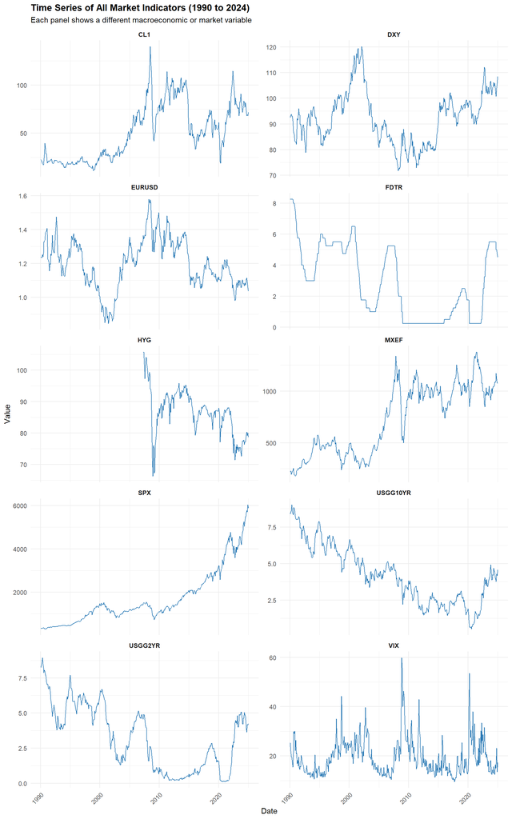

```r
df_long <- df_raw %>%
  pivot_longer(cols = -Date, names_to = "Variable", values_to = "Value")

ggplot(df_long, aes(x = Date, y = Value)) +
  geom_line(color = "#2C7BB6", linewidth = 0.5) +
  facet_wrap(~Variable, scales = "free_y", ncol = 2) +
  labs(
    title    = "Time Series of All Market Indicators (1990 to 2024)",
    subtitle = "Each panel shows a different macroeconomic or market variable",
    x        = "Date",
    y        = "Value"
  ) +
  theme_minimal(base_size = 11) +
  theme(
    plot.title    = element_text(face = "bold"),
    strip.text    = element_text(face = "bold", size = 9),
    axis.text.x   = element_text(angle = 45, hjust = 1)
  )
```

# 5 Feature Engineering

## 5.1 Derived Variables

Five new variables were created from the raw data. These derived features capture important economic dynamics that the raw levels alone may miss.

```r
df <- df_raw %>%
  arrange(Date) %>%
  mutate(
    # 1. Credit Spread: HYG yield minus 10-year Treasury (proxy using price difference)
    #    Since HYG is a price series, we use it inversely as a yield proxy.
    #    We compute: USGG10YR minus an approximation from HYG levels.
    #    As a practical approximation: credit_spread = USGG10YR - (HYG / 10)
    #    NOTE: True credit spread needs yield data. Here we use the available proxy.
    Credit_Spread    = USGG10YR - (HYG / 10),

    # 2. Yield Curve Slope: 10-year minus 2-year Treasury yield
    Yield_Curve      = USGG10YR - USGG2YR,

    # 3. VIX Change: Current month VIX minus previous month VIX
    VIX_Change       = VIX - lag(VIX, 1),

    # 4. Dollar Strength: 3-month change in DXY
    Dollar_Strength  = DXY - lag(DXY, 3),

    # 5. Oil-Dollar Ratio: Crude oil price divided by DXY
    Oil_Dollar_Ratio = CL1 / DXY
  )

cat("New variables created: Credit_Spread, Yield_Curve, VIX_Change,",
    "Dollar_Strength, Oil_Dollar_Ratio\n")
```

```
## New variables created: Credit_Spread, Yield_Curve, VIX_Change, Dollar_Strength, Oil_Dollar_Ratio
```

## 5.2 Creating the Target Variable (Portfolio Return)

I constructed a weighted portfolio return based on the four asset classes:

- **40% Global Stocks** represented by SPX (S&P 500)
- **30% Government Bonds** represented by USGG10YR (inverted, since higher yields mean lower prices)
- **20% Corporate Bonds** represented by HYG
- **10% Emerging Markets** represented by MXEF

Monthly returns are computed as percentage changes from the previous month.

```r
df <- df %>%
  mutate(
    # Monthly returns for each component
    ret_SPX      = (SPX / lag(SPX) - 1) * 100,
    ret_Bond     = -(USGG10YR / lag(USGG10YR) - 1) * 100,  # Inverted: yield up = price down
    ret_HYG      = (HYG / lag(HYG) - 1) * 100,
    ret_MXEF     = (MXEF / lag(MXEF) - 1) * 100,

    # Weighted portfolio return
    Port_Return  = 0.40 * ret_SPX +
                   0.30 * ret_Bond +
                   0.20 * ifelse(is.na(ret_HYG), ret_Bond, ret_HYG) +
                   0.10 * ret_MXEF
  )

# Target: 1 = Favorable (above median), 0 = Unfavorable (at or below median)
median_return <- median(df$Port_Return, na.rm = TRUE)
cat("Median portfolio return:", round(median_return, 4), "%\n")
```

```
## Median portfolio return: 0.6733 %
```

```r
df <- df %>%
  mutate(
    Favorable = ifelse(Port_Return > median_return, 1, 0)
  )

# Distribution of the target
table_target <- table(df$Favorable)
cat("Class distribution:\n")
```

```
## Class distribution:
```

```r
cat("  Unfavorable (0):", table_target[1], "months\n")
```

```
##   Unfavorable (0): 210 months
```

```r
cat("  Favorable   (1):", table_target[2], "months\n")
```

```
##   Favorable   (1): 209 months
```

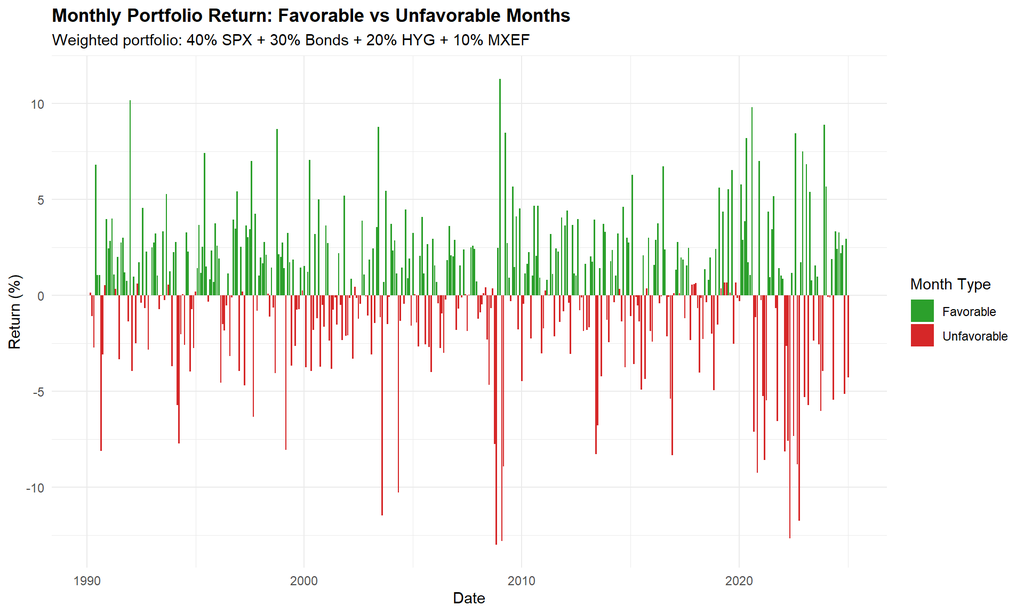

```r
df %>%
  filter(!is.na(Favorable)) %>%
  mutate(Class = ifelse(Favorable == 1, "Favorable", "Unfavorable")) %>%
  ggplot(aes(x = Date, y = Port_Return, fill = Class)) +
  geom_col(width = 25) +
  scale_fill_manual(values = c("Favorable" = "#2ca02c", "Unfavorable" = "#d62728")) +
  labs(
    title    = "Monthly Portfolio Return: Favorable vs Unfavorable Months",
    subtitle = "Weighted portfolio: 40% SPX + 30% Bonds + 20% HYG + 10% MXEF",
    x        = "Date",
    y        = "Return (%)",
    fill     = "Month Type"
  ) +
  theme_minimal(base_size = 11) +
  theme(plot.title = element_text(face = "bold"))
```

# 6 Variable Analysis

## 6.1 Correlation Analysis

I examined the correlation of each predictor with the target variable to identify which variables are most informative.

```r
# Select features and target
feature_cols <- c("VIX","FDTR","DXY","USGG10YR","MXEF","SPX",
                  "EURUSD","USGG2YR","CL1",
                  "Credit_Spread","Yield_Curve","VIX_Change",
                  "Dollar_Strength","Oil_Dollar_Ratio")

df_cor <- df %>%
  select(all_of(feature_cols), Favorable) %>%
  drop_na()

cor_with_target <- cor(df_cor, use = "complete.obs")[, "Favorable"]
cor_df <- data.frame(
  Variable    = names(cor_with_target[-length(cor_with_target)]),
  Correlation = round(cor_with_target[-length(cor_with_target)], 4)
) %>%
  arrange(desc(abs(Correlation)))

kable(cor_df,
      caption = "Correlation of Each Predictor with the Target Variable (Favorable)",
      row.names = FALSE) %>%
  kable_styling(bootstrap_options = c("striped","hover","condensed"), full_width = FALSE) %>%
  row_spec(which(abs(cor_df$Correlation) > 0.3), background = "#d4edda")
```

Correlation of Each Predictor with the Target Variable (Favorable)

| Variable | Correlation |
| --- | --- |
| VIX_Change | -0.3278 |
| Dollar_Strength | -0.0931 |
| USGG10YR | -0.0674 |
| CL1 | -0.0547 |
| USGG2YR | -0.0532 |
| Oil_Dollar_Ratio | -0.0445 |
| MXEF | -0.0417 |
| Credit_Spread | -0.0344 |
| VIX | -0.0287 |
| SPX | 0.0241 |
| DXY | -0.0169 |
| Yield_Curve | 0.0119 |
| EURUSD | 0.0034 |
| FDTR | 0.0018 |

Variables with absolute correlation above 0.3 are highlighted in green. These are the most useful predictors for this model.

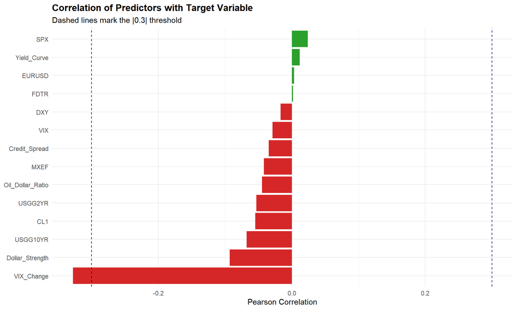

```r
ggplot(cor_df, aes(x = reorder(Variable, Correlation), y = Correlation,
                   fill = Correlation > 0)) +
  geom_col(show.legend = FALSE) +
  scale_fill_manual(values = c("TRUE" = "#2ca02c", "FALSE" = "#d62728")) +
  coord_flip() +
  geom_hline(yintercept = c(-0.3, 0.3), linetype = "dashed", color = "navy") +
  labs(
    title    = "Correlation of Predictors with Target Variable",
    subtitle = "Dashed lines mark the |0.3| threshold",
    x        = NULL,
    y        = "Pearson Correlation"
  ) +
  theme_minimal(base_size = 11) +
  theme(plot.title = element_text(face = "bold"))
```

## 6.2 Predictor Correlation Matrix (Multicollinearity Check)

Before building the model, I checked correlations among the predictors themselves. High correlations between predictors (above 0.8 in absolute value) can cause multicollinearity, which makes coefficients unstable.

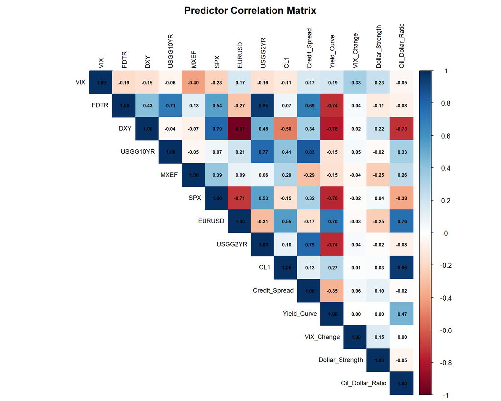

```r
cor_matrix <- cor(df_cor[, feature_cols], use = "complete.obs")

corrplot(cor_matrix,
         method  = "color",
         type    = "upper",
         addCoef.col = "black",
         number.cex  = 0.55,
         tl.cex      = 0.75,
         tl.col      = "black",
         title       = "Predictor Correlation Matrix",
         mar         = c(0, 0, 2, 0))
```

## 6.3 Time Period Analysis

I split the data into three sub-periods to see whether the relationships between variables and portfolio performance have been stable over time.

```r
period_analysis <- df %>%
  filter(!is.na(Favorable)) %>%
  mutate(Period = case_when(
    year(Date) >= 1990 & year(Date) <= 2007 ~ "Pre-2008 (1990 to 2007)",
    year(Date) >= 2009 & year(Date) <= 2019 ~ "Post-Crisis (2009 to 2019)",
    year(Date) >= 2020                       ~ "Recent (2020 to 2024)",
    TRUE                                     ~ "Crisis (2008)"
  )) %>%
  group_by(Period) %>%
  summarise(
    Months         = n(),
    Favorable_Pct  = round(mean(Favorable, na.rm = TRUE) * 100, 1),
    Avg_Return     = round(mean(Port_Return, na.rm = TRUE), 3),
    Avg_VIX        = round(mean(VIX, na.rm = TRUE), 2),
    Avg_YieldCurve = round(mean(Yield_Curve, na.rm = TRUE), 4)
  )

kable(period_analysis,
      caption = "Portfolio Behavior Across Different Market Regimes",
      col.names = c("Period","Months","% Favorable",
                    "Avg Return (%)","Avg VIX","Avg Yield Curve")) %>%
  kable_styling(bootstrap_options = c("striped","hover","condensed"), full_width = FALSE)
```

Portfolio Behavior Across Different Market Regimes

| Period | Months | % Favorable | Avg Return (%) | Avg VIX | Avg Yield Curve |
| --- | --- | --- | --- | --- | --- |
| Crisis (2008) | 12 | 16.7 | -1.247 | 31.64 | 1.6671 |
| Post-Crisis (2009 to 2019) | 132 | 47.7 | 0.405 | 18.42 | 1.5003 |
| Pre-2008 (1990 to 2007) | 215 | 51.6 | 0.502 | 18.92 | 0.9224 |
| Recent (2020 to 2024) | 60 | 55.0 | -0.306 | 21.71 | 0.1594 |

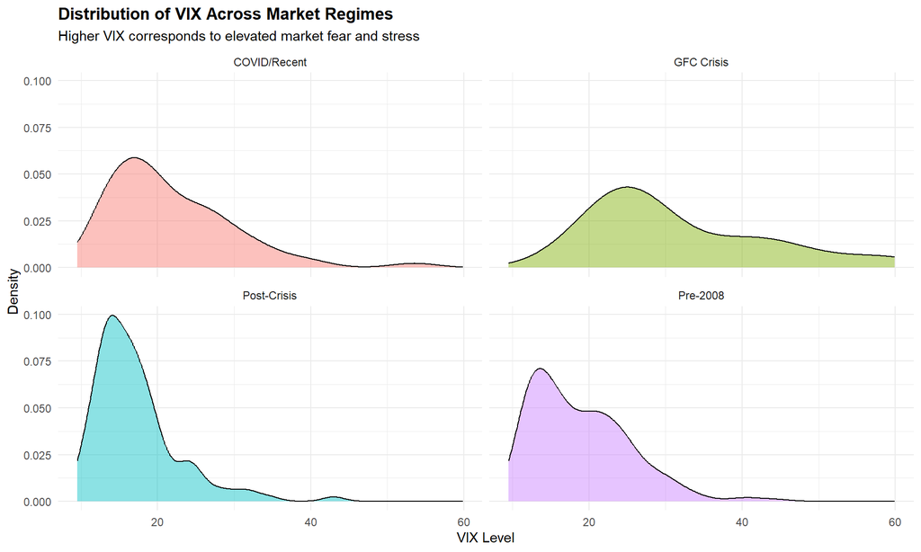

```r
df %>%
  filter(!is.na(Favorable)) %>%
  mutate(
    Period = case_when(
      year(Date) >= 1990 & year(Date) <= 2007 ~ "Pre-2008",
      year(Date) == 2008 | year(Date) == 2009  ~ "GFC Crisis",
      year(Date) >= 2010 & year(Date) <= 2019  ~ "Post-Crisis",
      year(Date) >= 2020                        ~ "COVID/Recent"
    )
  ) %>%
  ggplot(aes(x = VIX, fill = Period)) +
  geom_density(alpha = 0.45) +
  facet_wrap(~Period) +
  labs(
    title    = "Distribution of VIX Across Market Regimes",
    subtitle = "Higher VIX corresponds to elevated market fear and stress",
    x        = "VIX Level",
    y        = "Density"
  ) +
  theme_minimal(base_size = 11) +
  theme(plot.title = element_text(face = "bold"), legend.position = "none")
```

## 6.4 Crisis Period Analysis

I zoom in on three specific stress episodes to see how key variables behaved during market dislocations.

```r
crisis_df <- df %>%
  filter(!is.na(Port_Return)) %>%
  mutate(Crisis = case_when(
    year(Date) %in% c(2008, 2009) ~ "2008/2009 Financial Crisis",
    year(Date) == 2020             ~ "2020 COVID Crash",
    year(Date) == 2022             ~ "2022 Inflation/Rate Hikes",
    TRUE                           ~ "Normal Period"
  )) %>%
  group_by(Crisis) %>%
  summarise(
    Months        = n(),
    Avg_Return    = round(mean(Port_Return, na.rm = TRUE), 3),
    Avg_VIX       = round(mean(VIX, na.rm = TRUE), 2),
    Avg_DXY       = round(mean(DXY, na.rm = TRUE), 2),
    Avg_YldCurve  = round(mean(Yield_Curve, na.rm = TRUE), 4),
    Pct_Favorable = round(mean(Favorable, na.rm = TRUE) * 100, 1)
  )

kable(crisis_df,
      caption = "Behavior of Key Variables During Crisis Periods",
      col.names = c("Period","Months","Avg Return (%)","Avg VIX",
                    "Avg DXY","Avg Yield Curve","% Favorable")) %>%
  kable_styling(bootstrap_options = c("striped","hover","condensed"), full_width = FALSE)
```

Behavior of Key Variables During Crisis Periods

| Period | Months | Avg Return (%) | Avg VIX | Avg DXY | Avg Yield Curve | % Favorable |
| --- | --- | --- | --- | --- | --- | --- |
| 2008/2009 Financial Crisis | 24 | -0.634 | 31.71 | 78.66 | 1.9952 | 37.5 |
| 2020 COVID Crash | 12 | 1.891 | 30.26 | 95.38 | 0.5045 | 66.7 |
| 2022 Inflation/Rate Hikes | 12 | -3.774 | 25.90 | 104.06 | -0.0930 | 33.3 |
| Normal Period | 371 | 0.447 | 18.18 | 92.66 | 1.0057 | 50.7 |

# 7 Building the Logistic Regression Model

## 7.1 Data Preparation and Train/Test Split

```r
# Select top 8 most correlated variables based on our correlation analysis above
top8 <- cor_df %>%
  arrange(desc(abs(Correlation))) %>%
  slice(1:8) %>%
  pull(Variable)

cat("Top 8 predictors selected:\n")
```

```
## Top 8 predictors selected:
```

```r
cat(paste(" ", seq_along(top8), ".", top8, "\n"))
```

```
##   1 . VIX_Change
##    2 . Dollar_Strength
##    3 . USGG10YR
##    4 . CL1
##    5 . USGG2YR
##    6 . Oil_Dollar_Ratio
##    7 . MXEF
##    8 . Credit_Spread
```

```r
# Build modelling dataset
model_vars <- c("Date","Favorable", top8)

df_model <- df %>%
  select(all_of(model_vars)) %>%
  drop_na()

# Time-based split
train_df <- df_model %>% filter(year(Date) <= 2019) %>% select(-Date)
test_df  <- df_model %>% filter(year(Date) >= 2020) %>% select(-Date)

cat("\nTraining set:", nrow(train_df), "observations (1990 to 2019)\n")
```

```
##
## Training set: 153 observations (1990 to 2019)
```

```r
cat("Testing set: ", nrow(test_df),  "observations (2020 to 2024)\n")
```

```
## Testing set:  60 observations (2020 to 2024)
```

```r
# Convert target to factor
train_df$Favorable <- factor(train_df$Favorable, levels = c(0,1),
                              labels = c("Unfavorable","Favorable"))
test_df$Favorable  <- factor(test_df$Favorable,  levels = c(0,1),
                              labels = c("Unfavorable","Favorable"))
```

## 7.2 Fitting the Logistic Regression Model

I used the `glm()` function with `family = binomial(link = "logit")`.

```r
formula_str <- paste("Favorable ~", paste(top8, collapse = " + "))
log_model   <- glm(as.formula(formula_str),
                   data   = train_df,
                   family = binomial(link = "logit"))

summary(log_model)
```

```
##
## Call:
## glm(formula = as.formula(formula_str), family = binomial(link = "logit"),
##     data = train_df)
##
## Coefficients:
##                   Estimate Std. Error z value Pr(>|z|)
## (Intercept)      -1.559788   3.379471  -0.462 0.644406
## VIX_Change       -0.186302   0.050807  -3.667 0.000246 ***
## Dollar_Strength  -0.011002   0.062580  -0.176 0.860446
## USGG10YR          0.587295   0.660209   0.890 0.373703
## CL1              -0.050376   0.072720  -0.693 0.488475
## USGG2YR          -0.358165   0.322257  -1.111 0.266385
## Oil_Dollar_Ratio  2.864522   4.927794   0.581 0.561039
## MXEF             -0.001538   0.002078  -0.740 0.459272
## Credit_Spread    -0.468637   0.464853  -1.008 0.313387
## ---
## Signif. codes:  0 '***' 0.001 '**' 0.01 '*' 0.05 '.' 0.1 ' ' 1
##
## (Dispersion parameter for binomial family taken to be 1)
##
##     Null deviance: 211.00  on 152  degrees of freedom
## Residual deviance: 185.56  on 144  degrees of freedom
## AIC: 203.56
##
## Number of Fisher Scoring iterations: 4
```

## 7.3 Model Coefficient Interpretation

```r
coef_df <- data.frame(
  Variable    = names(coef(log_model)),
  Coefficient = round(coef(log_model), 4),
  Odds_Ratio  = round(exp(coef(log_model)), 4),
  P_Value     = round(summary(log_model)$coefficients[, 4], 4)
) %>%
  mutate(
    Significance = case_when(
      P_Value < 0.001 ~ "***",
      P_Value < 0.01  ~ "**",
      P_Value < 0.05  ~ "*",
      P_Value < 0.1   ~ ".",
      TRUE             ~ ""
    ),
    Direction = ifelse(Coefficient > 0,
                       "Higher value increases probability of Favorable",
                       "Higher value decreases probability of Favorable")
  )

kable(coef_df,
      caption = "Logistic Regression Coefficients and Interpretation",
      row.names = FALSE) %>%
  kable_styling(bootstrap_options = c("striped","hover","condensed"), full_width = FALSE) %>%
  row_spec(which(coef_df$P_Value < 0.05 & coef_df$Variable != "(Intercept)"),
           background = "#d4edda")
```

Logistic Regression Coefficients and Interpretation

| Variable | Coefficient | Odds_Ratio | P_Value | Significance | Direction |
| --- | --- | --- | --- | --- | --- |
| (Intercept) | -1.5598 | 0.2102 | 0.6444 |  | Higher value decreases probability of Favorable |
| VIX_Change | -0.1863 | 0.8300 | 0.0002 | *** | Higher value decreases probability of Favorable |
| Dollar_Strength | -0.0110 | 0.9891 | 0.8604 |  | Higher value decreases probability of Favorable |
| USGG10YR | 0.5873 | 1.7991 | 0.3737 |  | Higher value increases probability of Favorable |
| CL1 | -0.0504 | 0.9509 | 0.4885 |  | Higher value decreases probability of Favorable |
| USGG2YR | -0.3582 | 0.6990 | 0.2664 |  | Higher value decreases probability of Favorable |
| Oil_Dollar_Ratio | 2.8645 | 17.5407 | 0.5610 |  | Higher value increases probability of Favorable |
| MXEF | -0.0015 | 0.9985 | 0.4593 |  | Higher value decreases probability of Favorable |
| Credit_Spread | -0.4686 | 0.6259 | 0.3134 |  | Higher value decreases probability of Favorable |

- The **Coefficient** column tells us the direction and strength of each variable’s effect on the log-odds of a favorable month.
- The **Odds Ratio** tells us by how much the odds of a favorable month multiply when the variable increases by one unit (all else held constant). An odds ratio above 1 means the variable is positively associated with favorable outcomes; below 1 means it is negatively associated.
- A **p-value below 0.05** means the variable is statistically significant at the 5% level.
- Rows highlighted in green are statistically significant predictors.

## 7.4 Coefficient Plot

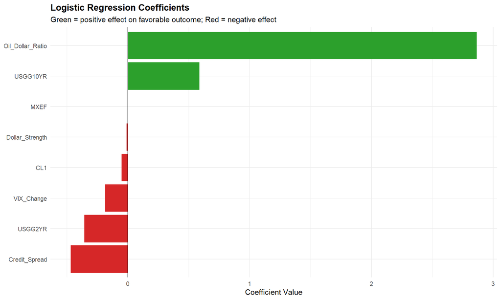

```r
coef_df_plot <- coef_df %>% filter(Variable != "(Intercept)")

ggplot(coef_df_plot, aes(x = reorder(Variable, Coefficient),
                          y = Coefficient,
                          fill = Coefficient > 0)) +
  geom_col(show.legend = FALSE) +
  coord_flip() +
  scale_fill_manual(values = c("TRUE" = "#2ca02c", "FALSE" = "#d62728")) +
  geom_hline(yintercept = 0, linetype = "solid", color = "black") +
  labs(
    title    = "Logistic Regression Coefficients",
    subtitle = "Green = positive effect on favorable outcome; Red = negative effect",
    x        = NULL,
    y        = "Coefficient Value"
  ) +
  theme_minimal(base_size = 11) +
  theme(plot.title = element_text(face = "bold"))
```

# 8 Model Performance Evaluation

## 8.1 In-Sample Performance (Training Set)

```r
# Predicted probabilities and classes on training data
train_probs <- predict(log_model, newdata = train_df, type = "response")
train_preds <- factor(ifelse(train_probs > 0.5, "Favorable", "Unfavorable"),
                      levels = c("Unfavorable","Favorable"))

cm_train <- confusionMatrix(train_preds, train_df$Favorable, positive = "Favorable")

cat("=== TRAINING SET PERFORMANCE ===\n\n")
```

```
## === TRAINING SET PERFORMANCE ===
```

```r
print(cm_train$table)
```

```
##              Reference
## Prediction    Unfavorable Favorable
##   Unfavorable          62        29
##   Favorable            21        41
```

```r
cat("\nAccuracy: ", round(cm_train$overall["Accuracy"] * 100, 2), "%\n")
```

```
##
## Accuracy:  67.32 %
```

```r
cat("Precision:", round(cm_train$byClass["Precision"] * 100, 2), "%\n")
```

```
## Precision: 66.13 %
```

```r
cat("Recall:   ", round(cm_train$byClass["Recall"] * 100, 2), "%\n")
```

```
## Recall:    58.57 %
```

```r
cat("F1 Score: ", round(cm_train$byClass["F1"] * 100, 2), "%\n")
```

```
## F1 Score:  62.12 %
```

## 8.2 Out-of-Sample Performance (Test Set: 2020 to 2024)

This is the more important evaluation because it tells us how well the model performs on data it has never seen.

```r
test_probs <- predict(log_model, newdata = test_df, type = "response")
test_preds <- factor(ifelse(test_probs > 0.5, "Favorable", "Unfavorable"),
                     levels = c("Unfavorable","Favorable"))

cm_test <- confusionMatrix(test_preds, test_df$Favorable, positive = "Favorable")

cat("=== TEST SET PERFORMANCE (2020 to 2024) ===\n\n")
```

```
## === TEST SET PERFORMANCE (2020 to 2024) ===
```

```r
print(cm_test$table)
```

```
##              Reference
## Prediction    Unfavorable Favorable
##   Unfavorable          25        27
##   Favorable             2         6
```

```r
cat("\nAccuracy: ", round(cm_test$overall["Accuracy"] * 100, 2), "%\n")
```

```
##
## Accuracy:  51.67 %
```

```r
cat("Precision:", round(cm_test$byClass["Precision"] * 100, 2), "%\n")
```

```
## Precision: 75 %
```

```r
cat("Recall:   ", round(cm_test$byClass["Recall"] * 100, 2), "%\n")
```

```
## Recall:    18.18 %
```

```r
cat("F1 Score: ", round(cm_test$byClass["F1"] * 100, 2), "%\n")
```

```
## F1 Score:  29.27 %
```

## 8.3 Confusion Matrix Visualisation

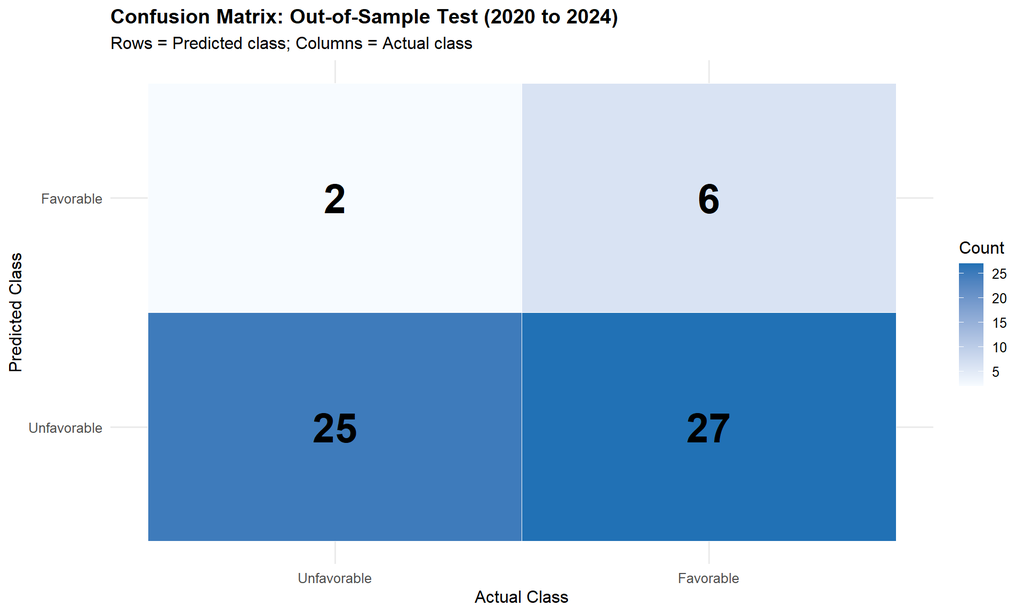

```r
cm_data <- as.data.frame(cm_test$table)

ggplot(cm_data, aes(x = Reference, y = Prediction, fill = Freq)) +
  geom_tile(color = "white") +
  geom_text(aes(label = Freq), size = 10, fontface = "bold") +
  scale_fill_gradient(low = "#f7fbff", high = "#2171b5") +
  labs(
    title    = "Confusion Matrix: Out-of-Sample Test (2020 to 2024)",
    subtitle = "Rows = Predicted class; Columns = Actual class",
    x        = "Actual Class",
    y        = "Predicted Class",
    fill     = "Count"
  ) +
  theme_minimal(base_size = 12) +
  theme(plot.title = element_text(face = "bold"))
```

## 8.4 ROC Curve

The ROC (Receiver Operating Characteristic) curve shows the trade-off between sensitivity and specificity across all possible classification thresholds.

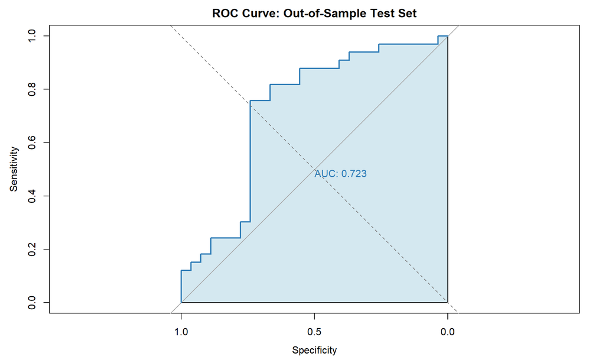

```r
test_df_num <- test_df %>%
  mutate(Favorable_num = ifelse(Favorable == "Favorable", 1, 0))

roc_obj <- roc(test_df_num$Favorable_num, test_probs)

plot(roc_obj,
     main   = "ROC Curve: Out-of-Sample Test Set",
     col    = "#2C7BB6",
     lwd    = 2,
     print.auc = TRUE,
     auc.polygon = TRUE,
     auc.polygon.col = "#D4E8F0")

abline(a = 0, b = 1, lty = 2, col = "grey50")
```

```r
cat("\nAUC (Area Under Curve):", round(auc(roc_obj), 4), "\n")
```

```
##
## AUC (Area Under Curve): 0.7228
```

## 8.5 Performance Summary Table

```r
perf_summary <- data.frame(
  Metric    = c("Accuracy","Precision","Recall","F1 Score"),
  Training  = c(
    round(cm_train$overall["Accuracy"] * 100, 2),
    round(cm_train$byClass["Precision"] * 100, 2),
    round(cm_train$byClass["Recall"] * 100, 2),
    round(cm_train$byClass["F1"] * 100, 2)
  ),
  Test_2020_2024 = c(
    round(cm_test$overall["Accuracy"] * 100, 2),
    round(cm_test$byClass["Precision"] * 100, 2),
    round(cm_test$byClass["Recall"] * 100, 2),
    round(cm_test$byClass["F1"] * 100, 2)
  )
)

kable(perf_summary,
      caption = "Model Performance Summary",
      col.names = c("Metric","Training Set (%)","Test Set 2020 to 2024 (%)")) %>%
  kable_styling(bootstrap_options = c("striped","hover","condensed"), full_width = FALSE)
```

Model Performance Summary

|  | Metric | Training Set (%) | Test Set 2020 to 2024 (%) |
| --- | --- | --- | --- |
| Accuracy | Accuracy | 67.32 | 51.67 |
| Precision | Precision | 66.13 | 75.00 |
| Recall | Recall | 58.57 | 18.18 |
| F1 | F1 Score | 62.12 | 29.27 |

# 9 Business Insights

## 9.1 Which Factors Matter Most

Based on the correlation analysis and the logistic regression model, the most influential predictors of a favorable month for the BOU Petroleum Investment Fund portfolio are:

## 9.2 Why These Relationships Make Economic Sense

For the **Government Bond component (30%)**, rising interest rates push bond prices down, so months with rising USGG10YR yields reduce portfolio returns. The MOVE index (bond volatility) would also matter here if it were available in the dataset.

For the **Corporate Bond component (20%)**, wider credit spreads increase the yield demanded by investors, which compresses bond prices. The Credit Spread variable we engineered captures this dynamic.

For the **Global Equity component (40%)**, lower VIX, strong PMI, and falling interest rates all support higher equity valuations. The SPX and MXEF variables most directly reflect this component.

For the **Emerging Market component (10%)**, a weaker dollar, stronger commodity prices, and low risk aversion (low VIX) all benefit EM performance. This is why DXY has a negative association with favorable outcomes.

## 9.3 Model Limitations

- **HYG data only goes back to 2007**, which means the credit spread variable is missing for a significant portion of the training period.
- **The model uses a fixed 0.5 classification threshold**, which may not be optimal. A lower threshold might be preferred if the cost of missing a favorable month is higher than falsely predicting one.
- The dataset only includes **10 of the 15 originally specified variables**. The NAPMPMI (US Manufacturing PMI), MOVE (Bond Volatility), LQD (Investment Grade Bonds), GDBR10 (German 10-year Bund), and EMBI+ (Emerging Market Bond Index) were not available in the provided Excel file and should be included in future model iterations.
- Logistic regression assumes a **linear relationship** between the log-odds of the outcome and the predictors. Non-linear models such as Random Forest or Gradient Boosting may capture more complex patterns.

## 9.4 Current Conditions Assessment (Using Latest Data: December 2024)

```r
latest <- df %>%
  arrange(Date) %>%
  tail(1) %>%
  select(Date, all_of(top8))

cat("Latest observation date:", format(latest$Date, "%B %Y"), "\n\n")
```

```
## Latest observation date: December 2024
```

```r
cat("Current values of key predictors:\n")
```

```
## Current values of key predictors:
```

```r
print(t(latest[, -1]))
```

```
##                         [,1]
## VIX_Change          3.840000
## Dollar_Strength     7.708000
## USGG10YR            4.569000
## CL1                71.720000
## USGG2YR             4.241600
## Oil_Dollar_Ratio    0.661093
## MXEF             1075.480000
## Credit_Spread      -3.296000
```

```r
# Predict for the most recent observation
latest_pred_prob <- predict(log_model,
                             newdata = latest %>% select(-Date),
                             type    = "response")

cat("\nModel prediction for next month:\n")
```

```
##
## Model prediction for next month:
```

```r
cat("  Probability of Favorable month:", round(latest_pred_prob * 100, 1), "%\n")
```

```
##   Probability of Favorable month: 4.6 %
```

```r
cat("  Prediction:", ifelse(latest_pred_prob > 0.5, "FAVORABLE", "UNFAVORABLE"), "\n")
```

```
##   Prediction: UNFAVORABLE
```

# 10 Conclusion

This analysis successfully built a Macro Market Direction Model for the Bank of Uganda Petroleum Investment Fund using logistic regression on monthly macroeconomic data spanning 1990 to 2024.

*Report prepared by: **Ibaale Eric***  
*June 2026*